# Introduccion a Rmarkdown

Evelia Coss

2023-10-13

```r
library(knitr)
library(tidyverse)
library(xaringanExtra)
library(icons)
library(fontawesome)
library(emo)
library(gt)
```

## 1. Informacion basica que compone a un Rmarkdown

## 2. Organizacion de la informacion

### Division de titulos

Los titulos se dividen por el simbolo `#`, de la siguiente manera:

```
# Genero Plantae (titulo principal)
## Plantas Verdes (sub1)
### Streptophyta (sub2)
#### Plantas terrestres (sub3)
##### Plantas vaculares (sub4)
```

### Letras en diferentes estilos

Puedes resaltar tu informacion colocando el simbolo `*` antes y despues del texto: Ejemplo: *italica*, **negritas** y *ambos tipos de estilo*.

### Listas

#### Simple (Una sola division):

- one
- two
- three

#### Compleja:

- one
- two
  - 2a
  - 2b
- three
  - 3a
    - 3rd layer
  - 2nd layer
- 1st layer

### Otro ejemplo:

1. item 10
   1. item 10a
   2. item 10b
2. item 11
   1. item 11a
   2. item 11b
3. item 12

## 3. Tipos de formatos generados para reportes con Rmarkdown

Con Rmarkdown puedes generar diversos archivos de salida como son:

- PDF
  - [Tesis ejemplo 1](https://ourcodingclub.github.io/tutorials/rmarkdown-dissertation/)
  - [Tesis ejemplo2](http://destio.us.es/calvo/memoriatfe/MemoriaTFE_PedroLuque_2017Nov_imprimir2caras.pdf)
  - [Curriculum vitae](https://elipapa.github.io/markdown-cv/)
- html
  - [Pagina web](https://bookdown.org/yihui/rmarkdown/html-document.html#table-of-contents)
  - [Presentaciones](https://bookdown.org/yihui/rmarkdown/xaringan.html)
- [Word](https://bookdown.org/yihui/rmarkdown/word-document.html)

## 4. Diferentes lenguajes empleados en Rmarkdown

### Rcode

```r
x= 'hello, world!'
x
```

```
## [1] "hello, world!"
```

### Bash

```bash
x=$(echo 'hello, world!')
echo $x
```

```
## hello, world!
```

## 5. Visualizacion grafica

### Ejemplo 2

Agregar linea entre puntos:

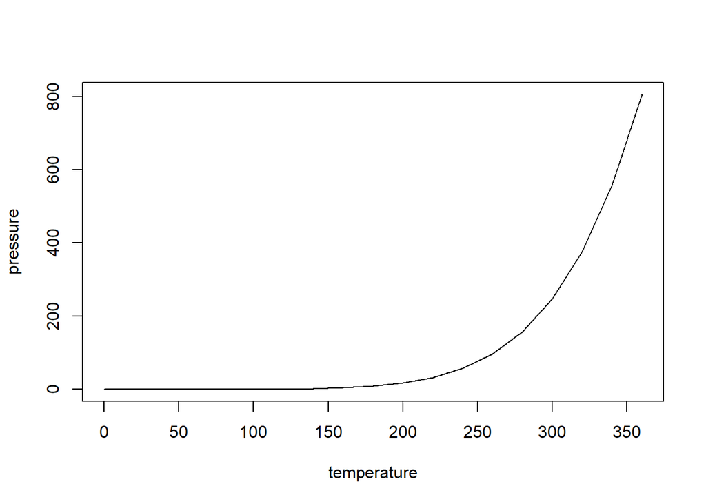

```r
plot(pressure, type="l")
```

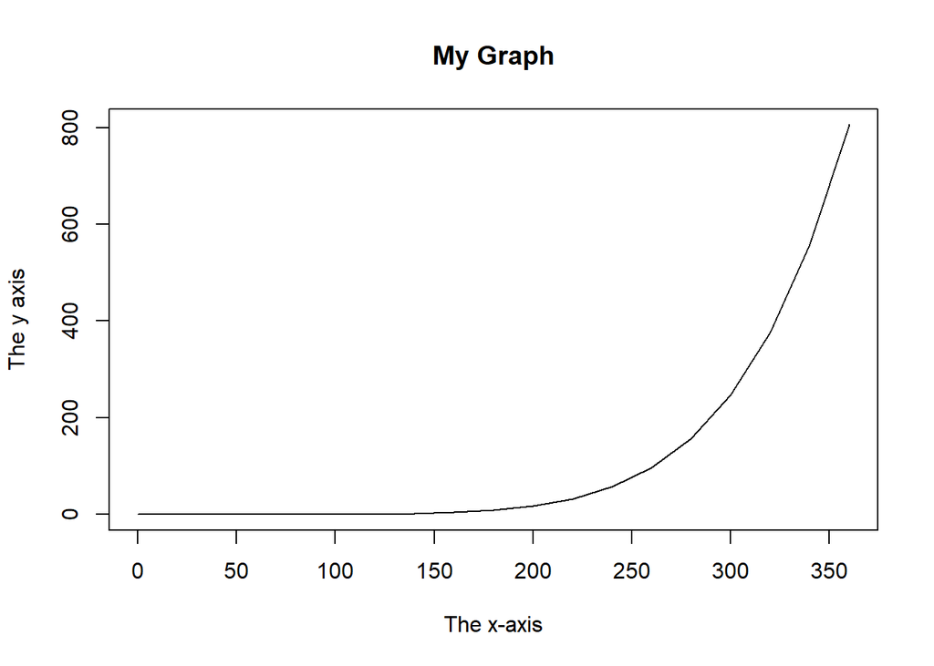

```r
plot(pressure, type="l", main="My Graph", xlab="The x-axis", ylab="The y axis")
```

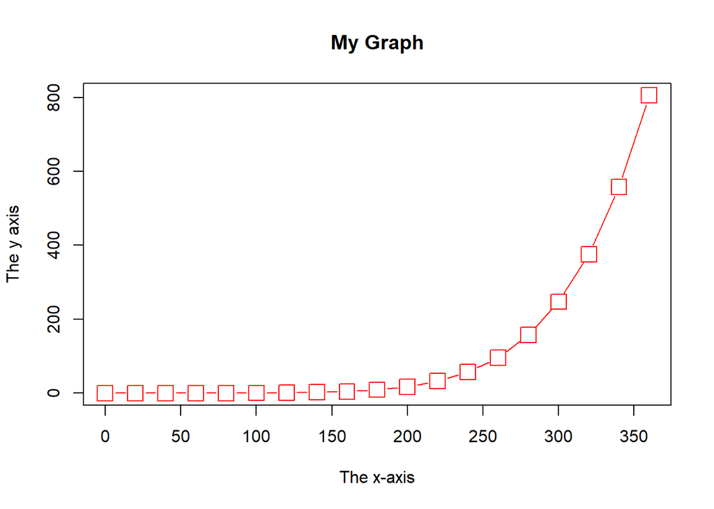

```r
plot(pressure, # dataframe
    type="b", # Tipo de grafico
    cex=2, # Tamano de los puntos
    pch = 0, # Forma del punto, valor de 0 a 25, el cero es un cuadrado
    main="My Graph", # titulo
    xlab="The x-axis", ylab="The y axis", # titulo en X y en Y
    col="red") # color de las lineas y puntos
```

```r
# type:
    # - "p" for points,
    # - "l" for lines,
    # - "b" for both,
    # - "c" for the lines part alone of "b",
    # - "o" for both ‘overplotted’,
    # - "h" for ‘histogram’ like (or ‘high-density’) vertical lines,
    # - "s" for stair steps,
    # - "S" for other steps, see ‘Details’ below,
    # - "n" for no plotting.
```

Guardar el grafico

```r
png(file="./pressure.png",  width=15, height=10, units="in", res=1200)

plot(pressure, # dataframe
    type="b", # Tipo de grafico
    cex=2, # Tamano de los puntos
    pch = 0, # Forma del punto, valor de 0 a 25, el cero es un cuadrado
    main="My Graph", # titulo
    xlab="The x-axis", ylab="The y axis", # titulo en X y en Y
    col="red") # color de las lineas y puntos

dev.off()
```

Para ver las otras opciones contenidas en la funcion `plot` puedes leer el [manual](https://www.rdocumentation.org/packages/graphics/versions/3.6.2/topics/plot).

Si quieres ver las diferentes formas que puedes hacer en los puntos, puedes leer la [guia](http://www.sthda.com/english/wiki/r-plot-pch-symbols-the-different-point-shapes-available-in-r).

Si quieres realizar otro tipo de grafica puedes visitar la [R graph gallery](https://r-graph-gallery.com/)

### Visualizar el contenido del dataframe

Si queremos analizar la informacion contenida en el dataframe `pressure` podemos emplear la funcion `head()`:

```r
head(pressure)
```

```
##   temperature pressure
## 1           0   0.0002
## 2          20   0.0012
## 3          40   0.0060
## 4          60   0.0300
## 5          80   0.0900
## 6         100   0.2700
```

Este dataframe contiene dos columnas: `temperature` y `pressure`.

Para ver las estadisticas de esta base de datos usamos `summary`:

```r
summary(pressure)
```

```
##   temperature     pressure
##  Min.   :  0   Min.   :  0.0002
##  1st Qu.: 90   1st Qu.:  0.1800
##  Median :180   Median :  8.8000
##  Mean   :180   Mean   :124.3367
##  3rd Qu.:270   3rd Qu.:126.5000
##  Max.   :360   Max.   :806.0000
```

## 6. Generar tablas

### Tabla simple

| Num | Header | Header2 | Header3 |
| --- | --- | --- | --- |
| 1 | first | 1st | One |
| 2 | second | 2nd | Two |
| 3 | third | 3rd | Three |

### Tabla en formato html

| Num | Header | Header2 | Header3 |
| --- | --- | --- | --- |
| 1 | first | 1st | One |
| 2 | second | 2nd | Two |
| 3 | third | 3rd | Three |

### Tablas de salida con kable

```r
iris %>%
  head() %>%
  knitr::kable(format = "html")
```

| Sepal.Length | Sepal.Width | Petal.Length | Petal.Width | Species |
| --- | --- | --- | --- | --- |
| 5.1 | 3.5 | 1.4 | 0.2 | setosa |
| 4.9 | 3.0 | 1.4 | 0.2 | setosa |
| 4.7 | 3.2 | 1.3 | 0.2 | setosa |
| 4.6 | 3.1 | 1.5 | 0.2 | setosa |
| 5.0 | 3.6 | 1.4 | 0.2 | setosa |
| 5.4 | 3.9 | 1.7 | 0.4 | setosa |

### Tablas con datatable

```r
iris %>%
  head(3) %>%
  DT::datatable()
```

|  | Sepal.Length | Sepal.Width | Petal.Length | Petal.Width | Species |
| --- | --- | --- | --- | --- | --- |
| 1 | 5.1 | 3.5 | 1.4 | 0.2 | setosa |
| 2 | 4.9 | 3 | 1.4 | 0.2 | setosa |
| 3 | 4.7 | 3.2 | 1.3 | 0.2 | setosa |

### [`library(gt)`](https://gt.rstudio.com/index.html)

```r
iris %>%
  head() %>%
  gt::gt() %>%
  gt::tab_spanner(label = "Petalo", columns = vars(Petal.Length,Petal.Width)) %>%
  gt::tab_spanner(label = "Sepalo", columns = vars(Sepal.Length,Sepal.Width))
```

[output not shown]

## 7. Agregar imagenes en un reporte

### Una imagen contenida como archivo

Ademas, podemos anexar archivos contenidos en nuestra computadora:

```r
knitr::include_graphics("figures/dplyr_joins.png")
```

[output not shown]

### Usando HTML

[figure not shown]

## 8. Realizar calculos en un texto

La suma de 4 mas 5 es 9.

La division de 4 entre 5 es 0.8.

La multiplicacion de 4 por 5 es 20.

Si 4^5 cuanto es? 1024

Redondear valores, 9.44 se redondea a 9.4

## 9. Lenguaje matematico

- Agregar ecuacion matematica

$$y = \mu + \sum_{i=1}^p \beta_i x_i +
\epsilon$$

- Agregar subindices para formulas CO<sub>2</sub>, alternativamente con `html` CO<sub>2</sub>
- Agregar super indice E=MC<sup>2</sup> o $E=MC^2$, alternativamente con `html` E=MC<sup>2</sup>

## 10. Agregar notas de ayuda

Para dar color a tus reportes puede agregar notas en los mismos dependiendo del contenido de la informacion:

Blue boxes (alert-info)

**Tip:** Use blue boxes (alert-info) for tips and notes.

Yellow boxes (alert-warning)

**Example:** Use yellow boxes for examples that are not inside code cells, or use for mathematical formulas if needed. Typically also used to display warning messages.

Green boxes (alert-success)

**Success:** This alert box indicates a successful or positive action.

Red boxes (alert-danger)

**Danger:** This alert box indicates a dangerous or potentially negative action.

## 11. Agregar citas o resaltar texto

### Una sola frase

> La belleza pierde su sentido cuando te rodea en exceso.

### Un parrafo completo

> La belleza pierde su sentido cuando te rodea en exceso.

> Pag. 41. El jardin de las mariposas. Dot Hutchison.

### Hacer mas compleja la cita

> La belleza pierde su sentido cuando te rodea en exceso.

> > La belleza depende de los ojos que la miran.

### Agregar elementos

#### Cosas por hacer:

> - Github de la clase de Rmarkdown.
> - Github de la clase de RNA-Seq.
> - Informacion de la pagina de JAGUAR.

> *Todo* va de acuerdo a lo **planeado**.

## 12. Generar indice en el reporte

Para finalizar podemos agregarle un indice a nuestro reporte editando la parte superior.

- Informacion incial

> title: “Introduccion a Rmarkdown”

> author: “Evelia Coss”

> date: “2023-01-30”

> output: html_document
- Informacion modificada para agregar el indice

> title: “Introduccion a Rmarkdown”

> author: “Evelia Coss”

> date: “2023-01-30”

> output: - html_document:
> - **toc: yes**
> - **toc_float: yes**
> - **toc_depth: 6**
> - **theme: cerulean**
- `toc` es para indicar que vas a agregar un indice en el reporte.
- `toc_float` es para indicar si el indice va a ser flotante o no, si indicas `yes` el indice se localizara a la izquiera de la pantalla y la informacion se desplegara cuando se coloques sobre ella.
- `toc_depth` es para indicar el numero de subtitulos que puedes tener en el archivo.
- `theme` es la decoracion del archivo.

Para mas temas puedes entrar al siguiente link: https://www.datadreaming.org/post/r-markdown-theme-gallery/

## 13. Configuración de los Chunks

En los chunks algunas cosas que se pueden especificar son: `{r setup1, include = FALSE, echo= FALSE, eval=FALSE}`:

- `include = FALSE`: no muestra el código.
- `echo = FALSE`: no muestra el resultado en el documento final.
- `warning = FALSE`: no muestra los warnings.
- `error = FALSE`: no muestra los mensajes de error.
- `message = FALSE`: no muestra los mensajes.
- `collapse = TRUE`: de ser posible colapsa la fuente y outputs de los bloques de código.
- `eval = FALSE`: no evalúa los códigos, sirve para mostrar bloques de código sin que emita resultados.
- `fig.dim = c(n,m)`: vector numérico para el tamaño de los plots.
- `fig.cap:"message"`:para colocar un caption a los plots.
- `highlight.output=c(n, m)`: resaltar líneas n,m del código.

Otras opciones para los chunks están [aquí](https://yihui.org/knitr/options/#chunk-options).